# Workshop: Plotting with GGPlot and Plotly

by Jeon Lee on January 18, 2020

### Data format and preparation

The data set mtcars is used in the examples below:

```r
library(ggplot2)
data(mtcars)
mtcars$cyl <- as.factor(mtcars$cyl)
head(mtcars[, c("wt", "mpg", "cyl")])
```

```
                     wt  mpg cyl
Mazda RX4         2.620 21.0   6
Mazda RX4 Wag     2.875 21.0   6
Datsun 710        2.320 22.8   4
Hornet 4 Drive    3.215 21.4   6
Hornet Sportabout 3.440 18.7   8
Valiant           3.460 18.1   6
```

### ggplot(): build plots piece by piece

- The quick and easy-to-use function: **qplot()**
- The more powerful and flexible function to build plots piece by piece: **ggplot()**

This section describes briefly how to use the function ggplot(). Recall that, the concept of ggplot divides a plot into three different fundamental parts: **plot = data + Aesthetics + geometry**.

- **data**: a data frame.
- **Aesthetics**: used to specify x and y variables, color, size, shape, ..
- **Geometry**: the type of plots (histogram, boxplot, line, density, dotplot, bar, .)

### Ex.1: Basic scatter plot

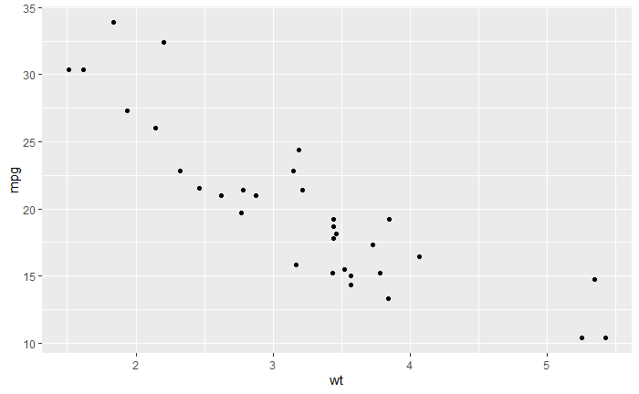

```r
# Basic scatter plot
ggplot(data = mtcars, aes(x = wt, y = mpg)) +
  geom_point()
```

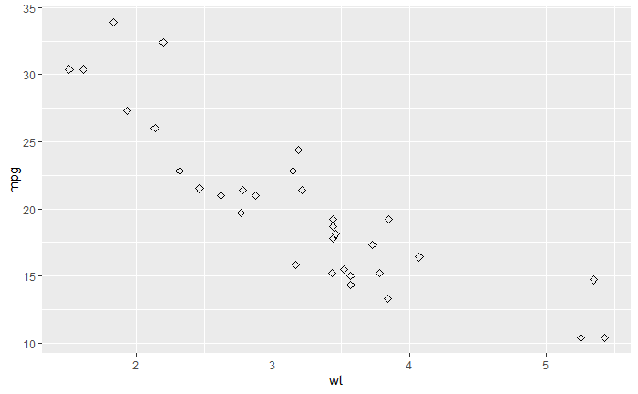

```r
# Change the point size, and shape
ggplot(mtcars, aes(x = wt, y = mpg)) +
  geom_point(size = 2, shape = 23)
```

### Ex.2: Adding layers to a scatter plot

Possible layers include:

- **geom_point()** for scatter plot
- **geom_smooth()** for adding smoothed line such as regression line
- **geom_quantile()** for adding quantile lines
- **geom_rug()** for adding a marginal rug
- **geom_jitter()** for avoiding overplotting
- **geom_text()** for adding textual annotations

#### a. geom_point(): Scatter plot

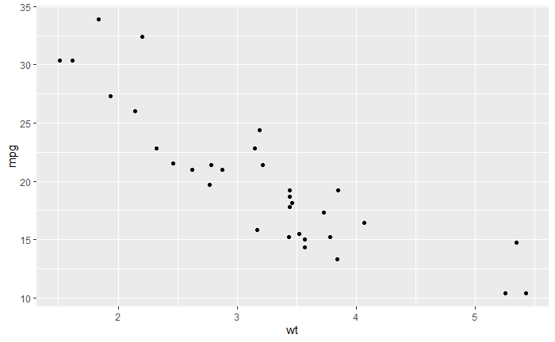

```r
p <- ggplot(mtcars, aes(x = wt, y = mpg))
# Basic plot
p + geom_point()
```

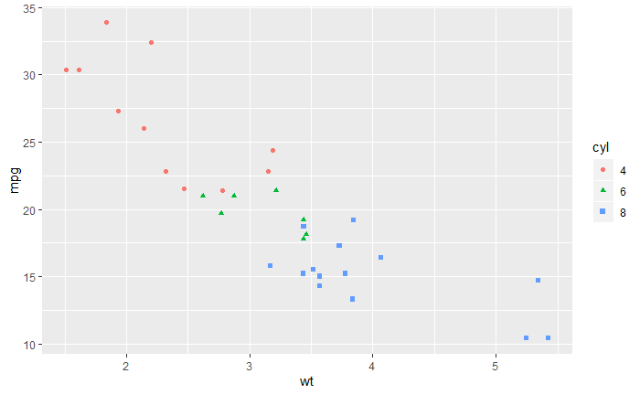

```r
# change the color and the point by the levels of cyl variable
p + geom_point(aes(color = cyl, shape = cyl))
```

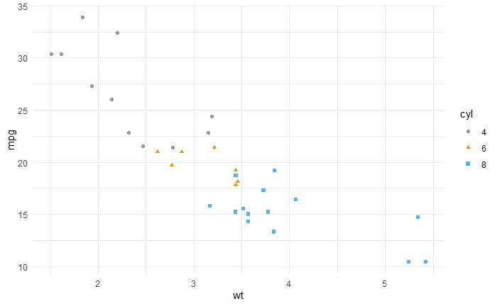

```r
# Change color manually: #999999; #E69F00; #56B4E9
p + geom_point(aes(color = cyl, shape = cyl)) +
  scale_color_manual(values = c("#999999", "#E69F00", "#56B4E9"))+
  theme_minimal()
```

#### b. geom_smooth(): Add regression line or smoothed conditional mean

To add a regression line on a scatter plot, the function **geom_smooth()** is used in combination with the argument **method = lm**. lm stands for linear model.

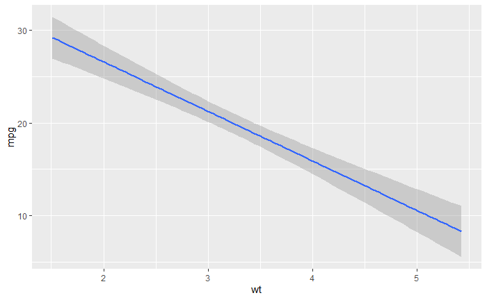

```r
# Regression line only
p + geom_smooth(method = lm)
```

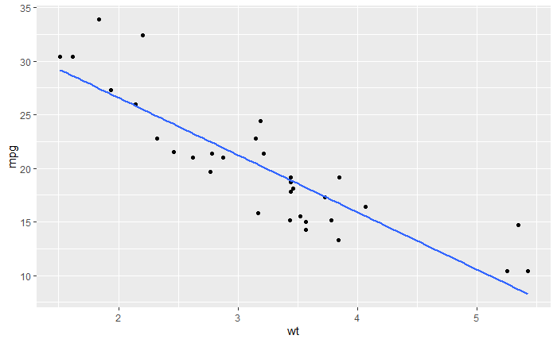

```r
# Point + regression line
# Remove the confidence interval
p + geom_point() +
  geom_smooth(method = lm, se = FALSE)
```

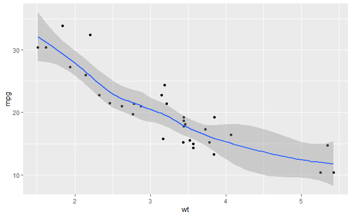

```r
# loess method: local regression fitting
p + geom_point() + geom_smooth()
```

[output not shown]

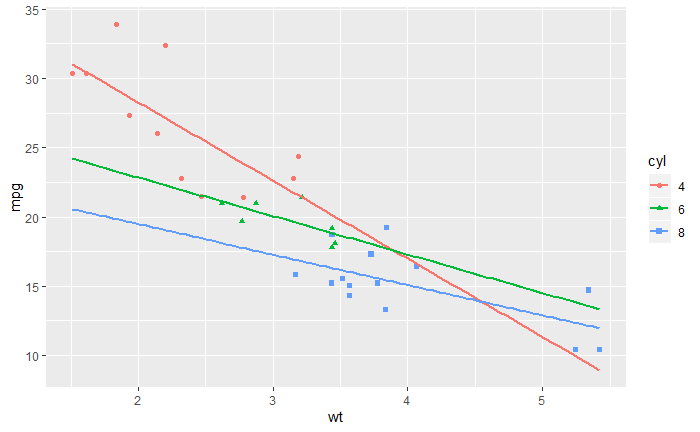

```r
# Change color and shape by groups (cyl)
p + geom_point(aes(color=cyl, shape=cyl)) +
  geom_smooth(aes(color=cyl, shape=cyl), method=lm, se=FALSE, fullrange=TRUE)
```